# 중간고사

통계적 방법론

2017-4-17

학번 ________________

이름 ________________

### BMI

1. 다음 중 `plot(rn96$height, rn96$weight)` 의 결과로 적합한 것은 무엇인가?

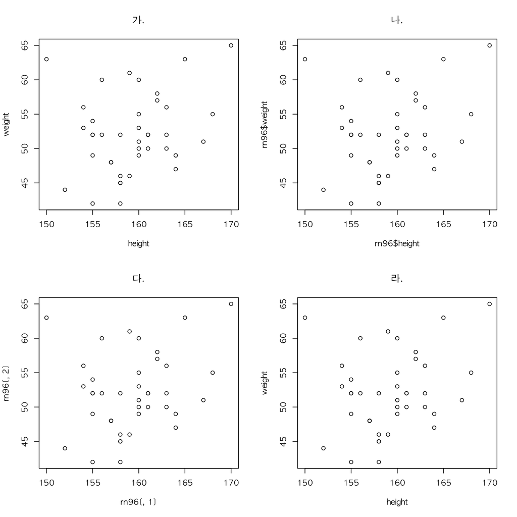

2. 다음 산점도에 회귀선을 그리는 데 적합한 것은 무엇인가?

   가. `lines(lm(weight ~ height, data = rn96)$coefficient)`

   나. `points(lm(weight ~ height, data = rn96)$coefficient)`

   다. `abline(lm(weight ~ height, data = rn96)$coefficient)`

   라. `polygon(lm(weight ~ height, data = rn96)$coefficient)`

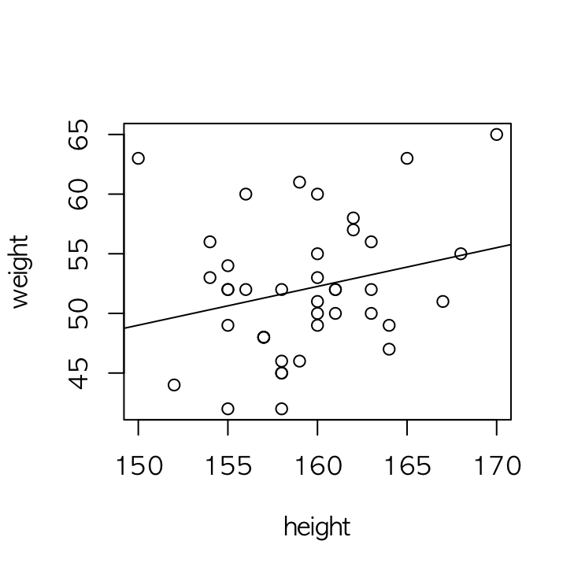

3. 1차 회귀식으로는 살피기 힘든 국소적인 변화를 살피기 위하여 붉은 색으로 local smoother를 추가한다. 이 때 적합한 것은?

   가. `lines(lowess(rn96$height, rn96$weight), col = "red")`

   나. `points(lowess(rn96$height, rn96$weight), col = "red")`

   다. `abline(lowess(rn96$height, rn96$weight), col = "red")`

   라. `polygon(lowess(rn96$height, rn96$weight), col = "red")`
4. BMI 를 토대로 한 비만도 판정은 “18.5 미만은 underweight, 18.5 ~ 24.9 는 Normal, 25 ~ 29.9 는 Overweight, 30 이상은 Obese” 이다. 이 때, `rn96` 에 판정결과를 덧붙이기 위하여 작성한 다음 코드에서 괄호 자리에 적당한 R 함수는 무엇인가?

   가. `ifelse`

   나. `if`

   다. `for`

   라. `while`

```
rn96$BMI <- BMI
(rn96$obesity <- (      )(BMI < 18.5, "Underweight", (      )(BMI >= 18.5 & BMI < 24.9, "Normal", (     )(BMI >= 25 & BMI < 29.9, "Overweight", "Obese"))))
```

### Quetelet’s Scottish Soldiers

5. 다음과 같이 그림 파일로 저장되어 있는 자료를 불러들이는 코드로 적절한 것은? 단, 그림의 폭을 기준으로 적절히 조절하고자 한다.

   가. `![Quetelet's frequency table](../pics/quetelet_soldiers.png)`

   나. `<img src = "../pics/quetelet_soldiers.png" width = "480"/>`

   다. `![Quetelet's frequency table](../pics/quetelet_soldiers.png, width = 480)`

   라. `<img src = "../pics/quetelet_soldiers.png" height = "640"/>`

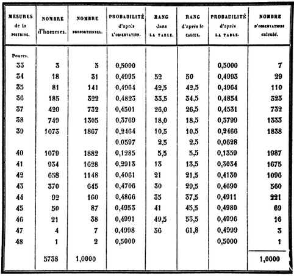

6. 아래와 같은 구조를 가진 `chest.table`에서 `"Freq"`를 추출하는 방법 중 그 결과가 다른 것은?

   가. `chest.table$Freq`

   나. `chest.table[, 2]`

   다. `chest.table[, "Freq"]`

   라. `chest.table["Freq"]`

```
## 'data.frame':    16 obs. of  2 variables:
##  $ Chest: int  33 34 35 36 37 38 39 40 41 42 ...
##  $ Freq : num  3 18 81 185 420 ...
```

7. 다음 `barplot`에서 막대 사이의 간격을 없애려면 어떤 조건을 넣어야 하는가?

   가. `names.arg = 33:48`

   나. `space = 0`

   다. `offset = 0`

   라. `beside = TRUE`

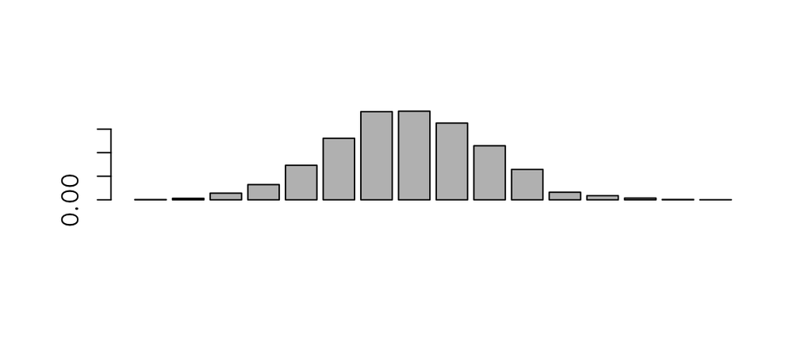

8. 아래 그림에서 빗금친 부분을 나타내기 위위해서 사용한 R 함수는 무엇인가?

   가. `plot`

   나. `lines`

   다. `abline`

   라. `polygon`

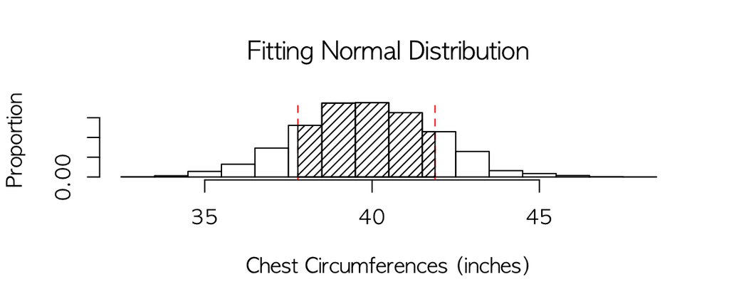

9. 위의 `chest.table` 데이터 프레임을 33인치 세번, 34인치가 18번 등으로 반복해서 나오는 한 줄의 벡터로 바꾸려면 어떤 방법이 적절한가?

   가. `rep(chest.table$Chest, chest.table$Freq`

   나. `rep(chest.table$Freq, chest.table$Chest)`

   다. `rep(chest.table$Chest, times = chest.table$Freq`

   라. `rep(chest.table$Freq, times = chest.table$Chest`

### Lifetable

#### 다음 소스코드와 출력결과물을 보고 물음에 답하시오.

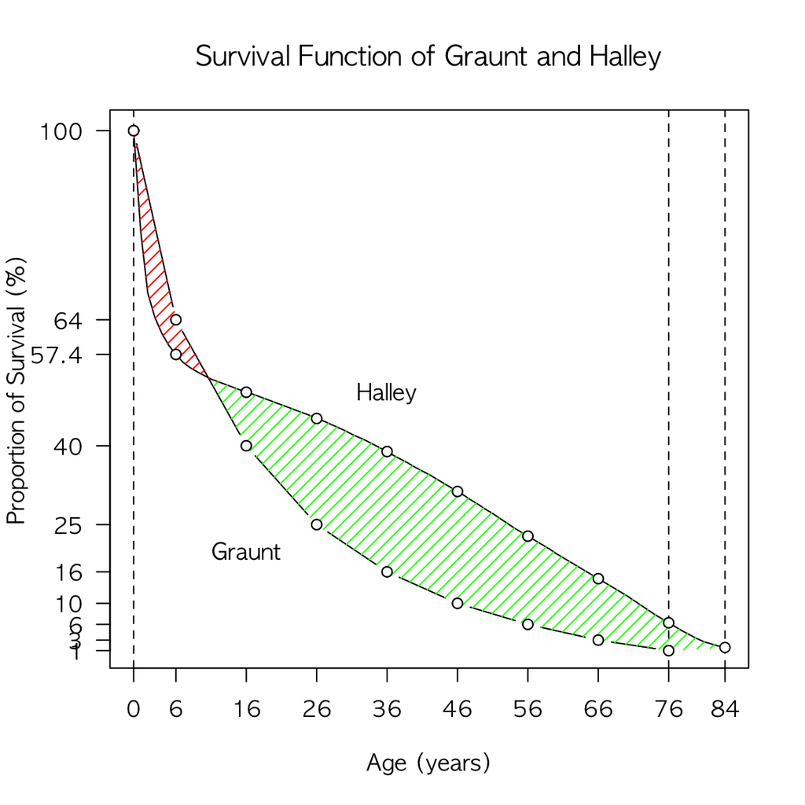

```r
plot(halley, ann = FALSE, xaxt = "n", yaxt = "n", type = "l")
abline(v = c(0, 76, 84), lty = 2)
points(halley.graunt, pch = 21, col = "black", bg = "white")
lines(graunt, type = "b", pch = 21, col = "black", bg = "white")
axis(side = 1, at = c(graunt$x, 84), labels = c(graunt$x, 84))
axis(side = 2, at = graunt$xPo.g, labels = graunt$xPo.g, las = 1)
axis(side = 2, at = xPo.halley.age.6, labels = xPo.halley.age.6, las = 1)
text(x = c(16, 36), y = c(20, 50), label = c("Graunt", "Halley"))
title(main = main.title.2, xlab = x.lab, ylab = y.lab)
polygon(poly.upper, angle = 45, density = 15, col = "red", border = NA)
polygon(poly.lower, angle = 45, density = 15, col = "green", border = NA)
points(graunt, pch = 21, col = "black", bg = "white")
points(halley.graunt, pch = 21, col = "black", bg = "white")
points(x = 84, y = halley$xPo[85], pch = 21, col = "black", bg = "white")
```

10. 이 중에서 도표의 제목을 사용자가 입력하기 위해서 집어넣은 조건은 무엇인가?

    가. `ann = FALSE`

    나. `xaxt = "n"`

    다. `yaxt = "n"`

    라. `type = "l"`
11. 관찰 연령의 시작과 끝을 뚜렷이 나타내기 위해서 사용한 코드는 무엇인가?

    가. `abline(v = c(0, 76, 84), lty = 2)`

    나. `axis(side = 1, at = c(graunt$x, 84), labels = c(graunt$x, 84))`

    다. `axis(side = 2, at = graunt$xPo.g, labels = graunt$xPo.g, las = 1)`

    라. `axis(side = 2, at = xPo.halley.age.6, labels = xPo.halley.age.6, las = 1)`
12. Halley 생존표에서만 관찰되는 6세 연령의 생존률을 $y$축에 표시하기 위하여 작성된 코드는 무엇인가?

    가. `abline(v = c(0, 76, 84), lty = 2)`

    나. `axis(side = 1, at = c(graunt$x, 84), labels = c(graunt$x, 84))`

    다. `axis(side = 2, at = graunt$xPo.g, labels = graunt$xPo.g, las = 1)`

    라. `axis(side = 2, at = xPo.halley.age.6, labels = xPo.halley.age.6, las = 1)`
13. 빗금친 부분을 표시하는 코드에서 굳이 넣지 않아도 되는 것은 무엇인가?

    가. `angle = 45`

    나. `density = 15`

    다. `col = "green"`

    라. `border = NA`
14. 이 코드 중에서 점의 윤곽을 뚜렷이 하기 위하여 작성된 부분은 어디인가?

    가. `abline(v = c(0, 76, 84), lty = 2)`

    나. `axis(side = 2, at = xPo.halley.age.6, labels = xPo.halley.age.6, las = 1)`

    다. `text(x = c(16, 36), y = c(20, 50), label = c("Graunt", "Halley"))`

    라. `points(graunt, pch = 21, col = "black", bg = "white")`
15. 아래의 reshaping 과정에서 factor를 설정하는 부분은 어디인가?

    가. `list(graunt.2, halley.2, us93.2)`

    나. `id.vars = "x"`

    다. `value.name = "xPo"`

    라. `variable.name = "Who"`

```r
ghu.melt <- melt(list(graunt.2, halley.2, us93.2), id.vars = "x", value.name = "xPo", variable.name = "Who")
```

#### 다음 소스코드와 출력결과물을 보고 물음에 답하시오.

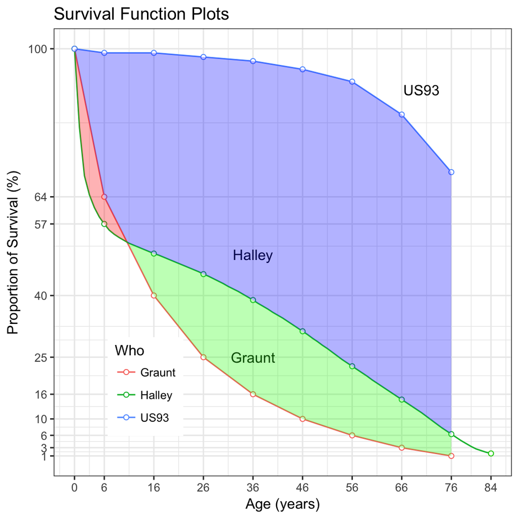

```r
(ghup <- ggplot() +
  geom_line(data = ghu.melt, aes(x = x, y = xPo, colour = Who)) +
  geom_point(data = ghu.melt.g, aes(x = x, y = xPo, colour = Who), shape = 21, fill = "white") +
  theme_bw() +
  xlab(x.lab) +
  ylab(y.lab) +
  ggtitle(main.title.3) +
  theme(legend.position = c(0.2, 0.2)) +
  annotate("text", x = c(36, 36, 70), y = c(25, 50, 90), label = c("Graunt", "Halley", "US93")) +
  scale_x_continuous(breaks = c(graunt$x, 84)) +
  scale_y_continuous(breaks = c(graunt$xPo.g, xPo.halley.age.6)) +
  geom_polygon(data = poly.upper, aes(x = x, y = y), alpha = 0.3, fill = "red") +
  geom_polygon(data = poly.lower.76, aes(x = x, y = y), alpha = 0.3, fill = "green") +
  geom_polygon(data = poly.us.76, aes(x = x, y = y), alpha = 0.3, fill = "blue") +
  geom_point(data = data.frame(x = 84, y = halley$xPo[85]), aes(x = x, y = y),  colour = 3, shape = 21, fill = "white"))
```

16. 뼈대가 되는 생존곡선을 그리는 과정에 각 집단을 구분하는 코드는 무엇인가?

    가. `x = x, y = xPo`

    나. `colour = Who`

    다. `shape = 21`

    라. `fill = "white"`
17. 도표의 배경을 흑백으로 바꿔주는 코드는 ?

    가. `theme_bw()`

    나. `xlab(x.lab)`

    다. `ylab(y.lab)`

    라. `ggtitle(main.title.3)`
18. 범례를 도표 안쪽으로 위치시키는 코드는 무엇인가?

    가. `theme(legend.position = c(0.2, 0.2))`

    나. `theme_bw()`

    다. `scale_x_continuous(breaks = c(graunt$x, 84))`

    라. `scale_y_continuous(breaks = c(graunt$xPo.g, xPo.halley.age.6))`
19. R의 Base Plot에서 `axis(side = 2, ...)`와 같은 기능을 수행하는 코드는 무엇인가?

    가. `theme(legend.position = c(0.2, 0.2))`

    나. `theme_bw()`

    다. `scale_x_continuous(breaks = c(graunt$x, 84))`

    라. `scale_y_continuous(breaks = c(graunt$xPo.g, xPo.halley.age.6))`
20. 색깔 투명도를 조절하는 코드는 무엇인가?

    가. `alpha = 0.3`

    나. `colour = Who`

    다. `shape = 21`

    라. `fill = "white"`